# Exploratory Data Analysis Report

Report by dlookr package

2020-01-06

# 1 Introduction

The EDA Report provides exploratory data analysis information on objects that inherit data.frame and data.frame.

## 1.1 Information of Dataset

The dataset that generated the EDA Report is an **‘data.frame’** object. It consists of **7,729 observations** and **27 variables**.

## 1.2 Information of Variables

The variable information of the data set that generated the EDA Report is shown in the following table.:

Information of Variables

| variables | types | missing_count | missing_percent | unique_count | unique_rate |
| --- | --- | --- | --- | --- | --- |
| job | factor | 0 | 0.0000000 | 7 | 0.0009057 |
| employer.trusted | factor | 26 | 0.3363954 | 3 | 0.0003881 |
| employer.has_logo | factor | 0 | 0.0000000 | 2 | 0.0002588 |
| address.lat | numeric | 2780 | 35.9684306 | 2856 | 0.3695174 |
| address.lng | numeric | 2780 | 35.9684306 | 2863 | 0.3704231 |
| address.metro.station | factor | 3770 | 48.7773321 | 226 | 0.0292405 |
| address.metro.line | factor | 3770 | 48.7773321 | 19 | 0.0024583 |
| experience | ordered | 0 | 0.0000000 | 4 | 0.0005175 |
| description | character | 0 | 0.0000000 | 7444 | 0.9631259 |
| key_skills | character | 0 | 0.0000000 | 4596 | 0.5946436 |
| accept_handicapped | factor | 0 | 0.0000000 | 2 | 0.0002588 |
| accept_kids | factor | 0 | 0.0000000 | 2 | 0.0002588 |
| specializations | character | 0 | 0.0000000 | 4665 | 0.6035710 |
| driver_license_types | character | 0 | 0.0000000 | 3 | 0.0003881 |
| has_test | factor | 0 | 0.0000000 | 2 | 0.0002588 |
| published_at | POSIXct | 0 | 0.0000000 | 7377 | 0.9544572 |
| created_at | POSIXct | 0 | 0.0000000 | 7377 | 0.9544572 |
| salary | numeric | 0 | 0.0000000 | 536 | 0.0693492 |
| employer.type | factor | 26 | 0.3363954 | 5 | 0.0006469 |
| employer.area | factor | 26 | 0.3363954 | 146 | 0.0188899 |
| employer.industries | factor | 26 | 0.3363954 | 1349 | 0.1745375 |
| employer.has_wiki | factor | 26 | 0.3363954 | 3 | 0.0003881 |
| employer.legal_form | factor | 7579 | 98.0592573 | 21 | 0.0027170 |
| employer.wiki_industry | factor | 7601 | 98.3438996 | 43 | 0.0055635 |
| employer.region | factor | 3696 | 47.8198991 | 5 | 0.0006469 |
| employer.founded.cat | ordered | 7343 | 95.0058222 | 6 | 0.0007763 |
| employer.class | ordered | 7657 | 99.0684435 | 5 | 0.0006469 |

The target variable of the data is **‘salary’**, and the data type of the variable is **numeric**.

## 1.3 About EDA Report

EDA reports provide information and visualization results that support the EDA process. In particular, it provides a variety of information to understand the relationship between the target variable and the rest of the variables of interest.

# 2 Univariate Analysis

## 2.1 Descriptive Statistics

edaData  
27 Variables 7729 Observations

job

| n | missing | distinct |
| --- | --- | --- |
| 7729 | 0 | 7 |

| lowest : | SMM-менеджер | Бухгалтер | Дизайнер | Маркетолог | Менеджер по персоналу |
| --- | --- | --- | --- | --- | --- |
| highest: | Дизайнер | Маркетолог | Менеджер по персоналу | Менеджер по продажам | Экономист |

SMM-менеджер (97, 0.013), Бухгалтер (1396, 0.181), Дизайнер (381, 0.049), Маркетолог (508, 0.066), Менеджер по персоналу (388, 0.050), Менеджер по продажам (4728, 0.612), Экономист (231, 0.030)

employer.trusted

| n | missing | distinct |
| --- | --- | --- |
| 7703 | 26 | 2 |

```
 Value      FALSE  TRUE
 Frequency    121  7582
 Proportion 0.016 0.984
```

employer.has_logo

| n | missing | distinct |
| --- | --- | --- |
| 7729 | 0 | 2 |

```
 Value      FALSE  TRUE
 Frequency   1477  6252
 Proportion 0.191 0.809
```

address.lat

| n | missing | distinct | Info | Mean | Gmd | .05 | .10 | .25 | .50 | .75 | .90 | .95 |
| --- | --- | --- | --- | --- | --- | --- | --- | --- | --- | --- | --- | --- |
| 4949 | 2780 | 2855 | 1 | 55.61 | 0.3548 | 55.62 | 55.65 | 55.71 | 55.75 | 55.79 | 55.84 | 55.87 |

lowest : 0.00000 4.16873 43.57885 48.68545 50.08441 , highest: 56.54387 56.87259 58.00723 59.78405 59.86627

```
 Value        0.0   4.0  43.5  48.5  50.0  51.5  55.0  55.5  56.0  56.5  57.0  58.0
 Frequency     10     1     3     1     2     1     2  2493  2430     2     1     1
 Proportion 0.002 0.000 0.001 0.000 0.000 0.000 0.000 0.504 0.491 0.000 0.000 0.000

 Value       60.0
 Frequency      2
 Proportion 0.000
```

For the frequency table, variable is rounded to the nearest 0.5

address.lng

| n | missing | distinct | Info | Mean | Gmd | .05 | .10 | .25 | .50 | .75 | .90 | .95 |
| --- | --- | --- | --- | --- | --- | --- | --- | --- | --- | --- | --- | --- |
| 4949 | 2780 | 2862 | 1 | 37.53 | 0.3393 | 37.41 | 37.45 | 37.54 | 37.61 | 37.66 | 37.73 | 37.78 |

lowest : 0.00000 14.42349 29.92534 30.32189 35.31694 , highest: 44.47455 46.02996 53.22710 56.24333 73.50636

```
 Value          0    14    30    35    37    38    39    40    44    46    53    56
 Frequency     10     2     2     1   767  4155     3     3     2     1     1     1
 Proportion 0.002 0.000 0.000 0.000 0.155 0.840 0.001 0.001 0.000 0.000 0.000 0.000

 Value         74
 Frequency      1
 Proportion 0.000
```

For the frequency table, variable is rounded to the nearest 1

address.metro.station

| n | missing | distinct |
| --- | --- | --- |
| 3959 | 3770 | 225 |

| lowest : | Авиамоторная | Автозаводская | Академическая | Александровский сад | Алексеевская |
| --- | --- | --- | --- | --- | --- |
| highest: | Щукинская | Электрозаводская | Юго-Западная | Южная | Ясенево |

address.metro.line

| n | missing | distinct |
| --- | --- | --- |
| 3959 | 3770 | 18 |

| lowest : | Арбатско-Покровская | Большая кольцевая линия | Бутовская | Замоскворецкая | Калининская |
| --- | --- | --- | --- | --- | --- |
| highest: | Некрасовская | Серпуховско-Тимирязевская | Сокольническая | Таганско-Краснопресненская | Филевская |

experience

| n | missing | distinct |
| --- | --- | --- |
| 7729 | 0 | 4 |

```
 Value               Нет опыта От 1 года до 3 лет      От 3 до 6 лет
 Frequency                1612               4097               1783
 Proportion              0.209              0.530              0.231

 Value             Более 6 лет
 Frequency                 237
 Proportion              0.031
```

description

| n | missing | distinct |
| --- | --- | --- |
| 7729 | 0 | 7444 |

| lowest : | - полное ведение бухгалтерского и налогового учета в 1:С 1:С "Предприятия 8.3" в соответствии с действующими законодательными нормами, инструкциями и положениями по нескольким юр. лицам на основной си… | «Диос недвижимость» - агентство недвижимости полного цикла было организовано в 1993 году. «Диос недвижимость» состоит в Российской Гильдии Риэлторов. Как социально ответственная компания, «Диос недвиж… | В стабильную компанию ТД "Колбасный Мир", в связи с расширением приглашаем МЕНЕДЖЕРА ПО РАБОТЕ С КЛИЕНТАМИ Должностные обязанности: Прием и обработка заказов клиентов, оформление первичной документаци… | Компания "ONE CARGO Express" более 9 лет на рынке услуг. В связи с расширением ищет в команду менеджера по продажам с перспективой карьерного роста до руководителя отдела продаж. Мы рады принять Вас в… | Обязанности: - ведение управленческого, бухгалтерского и налогового учета в полном объеме .два юр. лица УСНО и ОСНО проведение расчета заработной платы, компенсаций, больничных; начисление зарплаты (б… |
| --- | --- | --- | --- | --- | --- |
| highest: | Юридическая компания «Стерлинг» была создана в 2004 году с участием британской адвокатской фирмы «Стерлинг Скотланд Лтд». Благодаря переданному нам богатому опыту в сфере международных проектов, налог… | Юридическая компания работает в B2B секторе. ЛПР - руководители/владельцы компаний. Обязанности: работа с готовой клиентской базой; привлечение новых клиентов; выявление потребностей в юридических усл… | Юридическая фирма Cliff: 25 лет на рынке (основана в 1994 году), офисы в Москве, Лондоне, Кипре и Киеве. Собственная партнерская сеть в 70 юрисдикциях по всему миру. ТОП-5 лучших отраслевых практик в … | ЮСИМИ является официальным дилером мировых и эксклюзивных брендов обуви. В 2018 году было реализовано более 10000 пар обуви, в 2019 году рост составит более чем в два раза. Мы умеем продавать обувь он… | Яркая сеть спортивно-развлекательных Парков НЕБО активно развивается и, в связи с расширением штата, приглашает в свою команду Менеджера по персоналу Обязанности: Оперативное закрытие вакансий компани… |

key_skills

| n | missing | distinct |
| --- | --- | --- |
| 4843 | 2886 | 4595 |

| lowest : | -развитые навыки проведения переговоров, проактивность, аналитическое мышление::-умение работать системно при слаженном взаимодействии с параллельными структурными подразделениями::- успешный опыт раб… | 1C: Бухгалтерия | 1C: Бухгалтерия::1C: Зарплата и кадры::Банк-клиент::Консультант плюс::Первичная бухгалтерская документация::Бухгалтерская отчетность::1С: Предприятие 8::Кадровое делопроизводство::Пользователь ПК::1С:… | 1C: Бухгалтерия::1C: Зарплата и кадры::Бухгалтерская отчетность::Управление персоналом::Бухгалтерский учет::Налоговая отчетность | 1C: Бухгалтерия::1С: Бухгалтерия и склад::1С: Предприятие 8 |
| --- | --- | --- | --- | --- | --- |
| highest: | Яндекс.Директ::Яндекс.Метрика::Договорная работа::Реклама::Маркетинг услуг | Яндекс.Метрика::Digital Marketing::Креативность::SMM::Аудит SMM::Таргетинг::Cоциальная реклама::Social Media Marketing::Копирайтинг::Internet Marketing::Интернет маркетинг::Google Analytics::Медиаплан… | Яндекс.Метрика::Google Analytics::Adobe Photoshop::Продвижение бренда::Социальные сети | Яндекс.Метрика::Google Analytics::Google AdWords::Яндекс.Директ::Финансовая отчетность | Яндекс.Метрика::Интернет-реклама::SMM::SEO |

accept_handicapped

| n | missing | distinct |
| --- | --- | --- |
| 7729 | 0 | 2 |

```
 Value      FALSE  TRUE
 Frequency   7652    77
 Proportion  0.99  0.01
```

accept_kids

| n | missing | distinct |
| --- | --- | --- |
| 7729 | 0 | 2 |

```
 Value      FALSE  TRUE
 Frequency   7726     3
 Proportion     1     0
```

specializations

| n | missing | distinct |
| --- | --- | --- |
| 7729 | 0 | 4665 |

| lowest : | Автомобильный бизнес: Автозапчасти | Автомобильный бизнес: Автозапчасти::Автомобильный бизнес: Продажа | Автомобильный бизнес: Автозапчасти::Автомобильный бизнес: Продажа::Автомобильный бизнес: Начальный уровень, Мало опыта | Автомобильный бизнес: Автозапчасти::Автомобильный бизнес: Продажа::Автомобильный бизнес: Начальный уровень, Мало опыта::Продажи: Автомобили, Запчасти::Продажи: Начальный уровень, Мало опыта::Продажи: … | Автомобильный бизнес: Автозапчасти::Автомобильный бизнес: Продажа::Автомобильный бизнес: Начальный уровень, Мало опыта::Продажи: Автомобили, Запчасти::Продажи: Продавец в магазине::Начало карьеры, сту… |
| --- | --- | --- | --- | --- | --- |
| highest: | Юристы: Недвижимость::Юристы: Начальный уровень, Мало опыта::Производство, сельское хозяйство: Начальный уровень, Мало опыта::Строительство, недвижимость: Агент::Строительство, недвижимость: Начальный… | Юристы: Недвижимость::Юристы: Начальный уровень, Мало опыта::Строительство, недвижимость: Агент::Строительство, недвижимость: Жилье::Строительство, недвижимость: Начальный уровень, Мало опыта::Продажи… | Юристы: Недвижимость::Юристы: Начальный уровень, Мало опыта::Строительство, недвижимость: Агент::Строительство, недвижимость: Начальный уровень, Мало опыта::Консультирование: Начальный уровень, Мало о… | Юристы: Недвижимость::Юристы: Юрисконсульт::Юристы: Международное право::Консультирование: Реинжиниринг, Аутсорсинг финансовой функции::Продажи: Финансовые услуги | Юристы: Юрисконсульт |

driver_license_types

| n | missing | distinct |
| --- | --- | --- |
| 63 | 7666 | 2 |

```
 Value          B B::BE
 Frequency     62     1
 Proportion 0.984 0.016
```

has_test

| n | missing | distinct |
| --- | --- | --- |
| 7729 | 0 | 2 |

```
 Value      FALSE  TRUE
 Frequency   7586   143
 Proportion 0.981 0.019
```

published_at

```
                   n             missing            distinct                Info
                7729                   0                7377                   1
                Mean                 Gmd                 .05                 .10
 2019-12-22 10:40:56             1052667 2019-12-04 05:27:42 2019-12-06 08:02:30
                 .25                 .50                 .75                 .90
 2019-12-12 14:50:23 2019-12-23 14:12:46 2020-01-02 11:10:19 2020-01-04 07:05:27
                 .95
 2020-01-04 11:44:38
```

| lowest : | 2019-12-01 08:14:09 | 2019-12-01 08:29:31 | 2019-12-01 09:20:58 | 2019-12-01 12:40:21 | 2019-12-01 12:58:52 |
| --- | --- | --- | --- | --- | --- |
| highest: | 2020-01-06 13:28:31 | 2020-01-06 13:32:47 | 2020-01-06 13:36:10 | 2020-01-06 13:40:15 | 2020-01-06 13:44:31 |

created_at

```
                   n             missing            distinct                Info
                7729                   0                7377                   1
                Mean                 Gmd                 .05                 .10
 2019-12-22 10:40:56             1052667 2019-12-04 05:27:42 2019-12-06 08:02:30
                 .25                 .50                 .75                 .90
 2019-12-12 14:50:23 2019-12-23 14:12:46 2020-01-02 11:10:19 2020-01-04 07:05:27
                 .95
 2020-01-04 11:44:38
```

| lowest : | 2019-12-01 08:14:09 | 2019-12-01 08:29:31 | 2019-12-01 09:20:58 | 2019-12-01 12:40:21 | 2019-12-01 12:58:52 |
| --- | --- | --- | --- | --- | --- |
| highest: | 2020-01-06 13:28:31 | 2020-01-06 13:32:47 | 2020-01-06 13:36:10 | 2020-01-06 13:40:15 | 2020-01-06 13:44:31 |

salary

| n | missing | distinct | Info | Mean | Gmd | .05 | .10 | .25 | .50 | .75 | .90 | .95 |
| --- | --- | --- | --- | --- | --- | --- | --- | --- | --- | --- | --- | --- |
| 7729 | 0 | 536 | 0.999 | 79554 | 38715 | 37534 | 43027 | 52500 | 72450 | 95000 | 125000 | 152840 |

lowest : 11250 13920 15225 17400 18000 , highest: 348000 350000 375000 435000 450000

employer.type

| n | missing | distinct |
| --- | --- | --- |
| 7703 | 26 | 4 |

```
 Value                 agency           company private_recruiter  project_director
 Frequency                694              6913                23                73
 Proportion             0.090             0.897             0.003             0.009
```

employer.area

| n | missing | distinct |
| --- | --- | --- |
| 7703 | 26 | 145 |

| lowest : | Австрия | Аксай (Ростовская область) | Алматы | Алушта | Арциз |
| --- | --- | --- | --- | --- | --- |
| highest: | Щербинка | Электросталь | Электроугли | Эстония | Ярославль |

employer.industries

| n | missing | distinct |
| --- | --- | --- |
| 7703 | 26 | 1348 |

| lowest : |  | Авиаперевозки | Авиаперевозки::Железнодорожные перевозки | Авиационная, вертолетная, аэрокосмическая промышленность | Авиационная, вертолетная, аэрокосмическая промышленность::Двигатели (монтаж, сервис, ремонт) |
| --- | --- | --- | --- | --- | --- |
| highest: | Ювелирные изделия, бижутерия (продвижение, оптовая торговля)::Ювелирные изделия, бижутерия (производство) | Юридическое обслуживание | Юридическое обслуживание::Аудит, управленческий учет, финансово-юридический консалтинг | Юридическое обслуживание::Интернет-компания (поисковики, платежные системы, соц.сети, информационно-познавательные и развлекательные ресурсы, продвижение сайтов и прочее)::Разработка программного обес… | Юридическое обслуживание::Услуги по ведению бухгалтерского и налогового учета, расчет заработной платы::Аудит, управленческий учет, финансово-юридический консалтинг |

employer.has_wiki

| n | missing | distinct |
| --- | --- | --- |
| 7703 | 26 | 2 |

```
 Value      FALSE  TRUE
 Frequency   7270   433
 Proportion 0.944 0.056
```

employer.legal_form

| n | missing | distinct |
| --- | --- | --- |
| 150 | 7579 | 20 |

| lowest : | AG в Австрии | akciova spolecnost | Aktiengesellschaft | GmbH & Co. KG | Oy |
| --- | --- | --- | --- | --- | --- |
| highest: | публичная компания | публичное акционерное общество | унитарное предприятие | фонд | частная компания |

employer.wiki_industry

| n | missing | distinct |
| --- | --- | --- |
| 128 | 7601 | 42 |

| lowest : | авиакосмическая промышленность | авиационная промышленность | автомобильная промышленность | Автомобильный дилер | АСУ ТП |
| --- | --- | --- | --- | --- | --- |
| highest: | целлюлозно-бумажная промышленность | чёрная металлургия | швейная промышленность | электронная коммерция | электросвязь |

employer.region

| n | missing | distinct |
| --- | --- | --- |
| 4033 | 3696 | 4 |

```
 Value      быв. СССР    Другой     Запад    Россия
 Frequency          6         4        39      3984
 Proportion     0.001     0.001     0.010     0.988
```

employer.founded.cat

| n | missing | distinct |
| --- | --- | --- |
| 386 | 7343 | 5 |

| lowest : | Extremely old | Old | X | Y | Z |
| --- | --- | --- | --- | --- | --- |
| highest: | Extremely old | Old | X | Y | Z |

```
 Value      Extremely old           Old             X             Y             Z
 Frequency             35            66            68           196            21
 Proportion         0.091         0.171         0.176         0.508         0.054
```

employer.class

| n | missing | distinct |
| --- | --- | --- |
| 72 | 7657 | 4 |

```
 Value        Малое предприятие Среднее предприятие Крупное предприятие
 Frequency                    1                   6                  47
 Proportion               0.014               0.083               0.653

 Value               Корпорация
 Frequency                   18
 Proportion               0.250
```

## 2.2 Normality Test of Numerical Variables

### 2.2.1 Statistics and Visualization of (Sample) Data

**[ address.lat ]**

normality test : Shapiro-Wilk normality test

statistic : 0.03053, p-value : 1.55361E-83

skewness and kurtosis

| type | skewness | kurtosis |
| --- | --- | --- |
| original | -35.33580 | 1329.801 |
| log transformation | NaN | NaN |
| sqrt transformation | -38.49289 | 1515.462 |

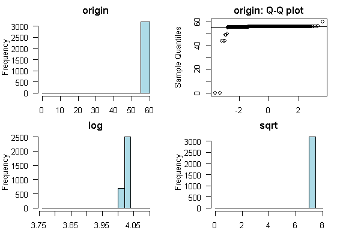

**[ address.lng ]**

normality test : Shapiro-Wilk normality test

```
 statistic : 0.06364,  p-value : 1.36067E-82
```

skewness and kurtosis

| type | skewness | kurtosis |
| --- | --- | --- |
| original | -8.049007 | 272.7818 |
| log transformation | NaN | NaN |
| sqrt transformation | -17.518281 | 349.5188 |

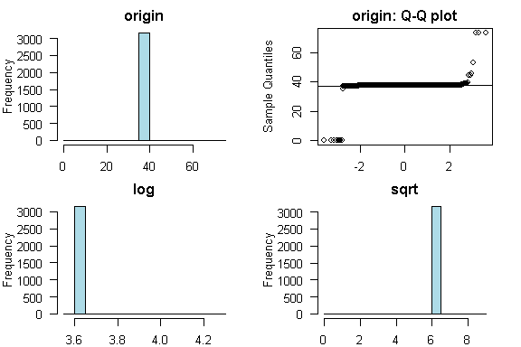

# 3 Relationship Between Variables

## 3.1 Correlation Coefficient

### 3.1.1 Correlation Coefficient by Variable Combination

```
Number of numerical variables is less than 2.
```

### 3.1.2 Correlation Plot of Numerical Variables

```
Number of numerical variables is less than 2.
```

# 4 Target based Analysis

## 4.1 Grouped Descriptive Statistics

### 4.1.1 Grouped Numerical Variables

**[ address.lat ]**

Simple Linear Model Information

```
 Residual standard error: 38193 on 4947 degrees of freedom
 Multiple R-squared:  0.00001,  Adjusted R-squared:  -0.00019
 F-statistic: 0 on 1 and 4947 DF,  p-value: 0.831439143985145
```

Coefficients:

Simple Linear Model coefficients : address.lat

|  | Estimate | Std. Error | t value | Pr(>\|t\|) |
| --- | --- | --- | --- | --- |
| (Intercept) | 80866.02 | 11482.84 | 7.04 | 0.00 |
| address.lat | -43.90 | 206.24 | -0.21 | 0.83 |

Visualization:

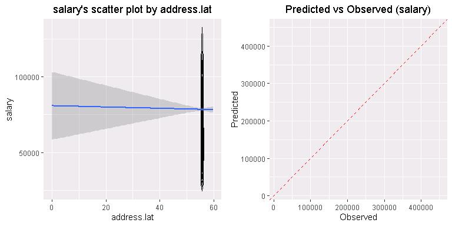

**[ address.lng ]**

Simple Linear Model Information

```
 Residual standard error: 38193 on 4947 degrees of freedom
 Multiple R-squared:  0.00001,  Adjusted R-squared:  -0.0002
 F-statistic: 0 on 1 and 4947 DF,  p-value: 0.860600634872194
```

Coefficients:

Simple Linear Model coefficients : address.lng

|  | Estimate | Std. Error | t value | Pr(>\|t\|) |
| --- | --- | --- | --- | --- |
| (Intercept) | 80331.45 | 10872.45 | 7.39 | 0.00 |
| address.lng | -50.81 | 289.32 | -0.18 | 0.86 |

Visualization:

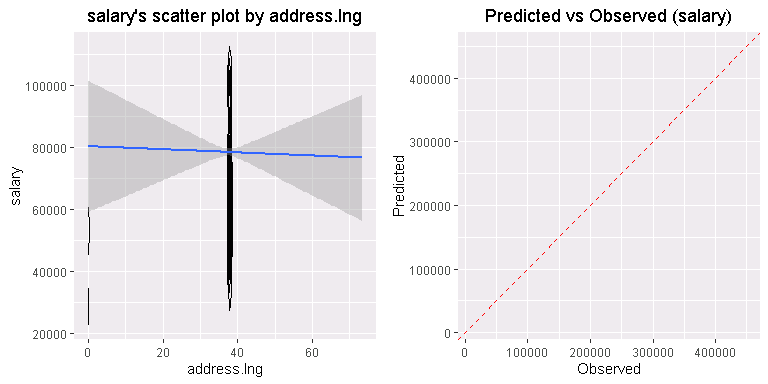

### 4.1.2 Grouped Categorical Variables

**[ job ]**  
1. Analysis of Variance

Analysis of Variance Table : job

|  | Df | Sum.Sq | Mean.Sq | F.value | Pr..F. |
| --- | --- | --- | --- | --- | --- |
| job | 6 | 887071087677 | 147845181279 | 108.52 | 0 |
| Residuals | 7722 | 10520377230823 | 1362390214 | NA | NA |

2. Simple Linear Model Information

Coefficients:

Simple Linear Model coefficients : job

|  | Estimate | Std. Error | t value | Pr(>\|t\|) |
| --- | --- | --- | --- | --- |
| (Intercept) | 62710.29 | 3747.70 | 16.73 | 0.00 |
| jobБухгалтер | -447.24 | 3875.72 | -0.12 | 0.91 |
| jobДизайнер | 15491.09 | 4197.75 | 3.69 | 0.00 |
| jobМаркетолог | 23737.64 | 4089.88 | 5.80 | 0.00 |
| jobМенеджер по персоналу | -3306.32 | 4190.06 | -0.79 | 0.43 |
| jobМенеджер по продажам | 23851.33 | 3785.95 | 6.30 | 0.00 |
| jobЭкономист | 5908.05 | 4465.76 | 1.32 | 0.19 |

3. Visualization:

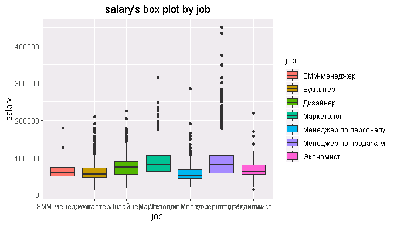

**[ employer.trusted ]**  
1. Analysis of Variance

Analysis of Variance Table : employer.trusted

|  | Df | Sum.Sq | Mean.Sq | F.value | Pr..F. |
| --- | --- | --- | --- | --- | --- |
| employer.trusted | 1 | 3351975151 | 3351975151 | 2.27 | 0.13 |
| Residuals | 7701 | 11384040200275 | 1478254798 | NA | NA |

2. Simple Linear Model Information

Residual standard error: 38448 on 7701 degrees of freedom Multiple R-squared: 0.00029, Adjusted R-squared: 0.00016 F-statistic: 2 on 1 and 7701 DF, p-value: 0.132152010500989

Coefficients:

Simple Linear Model coefficients : employer.trusted

|  | Estimate | Std. Error | t value | Pr(>\|t\|) |
| --- | --- | --- | --- | --- |
| (Intercept) | 84767.61 | 3495.28 | 24.25 | 0.00 |
| employer.trustedTRUE | -5305.13 | 3523.06 | -1.51 | 0.13 |

3. Visualization:

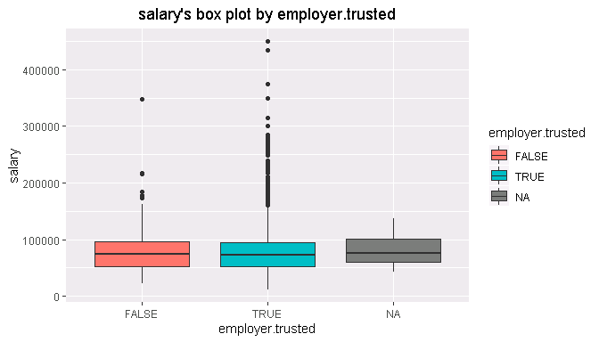

**[ employer.has_logo ]**  
1. Analysis of Variance

Analysis of Variance Table : employer.has\_logo

|  | Df | Sum.Sq | Mean.Sq | F.value | Pr..F. |
| --- | --- | --- | --- | --- | --- |
| employer.has_logo | 1 | 43156924483 | 43156924483 | 29.34 | 0 |
| Residuals | 7727 | 11364291394018 | 1470724912 | NA | NA |

2. Simple Linear Model Information

Residual standard error: 38350 on 7727 degrees of freedom Multiple R-squared: 0.00378, Adjusted R-squared: 0.00365 F-statistic: 29 on 1 and 7727 DF, p-value: 0.0000000624288150171863

Coefficients:

Simple Linear Model coefficients : employer.has\_logo

|  | Estimate | Std. Error | t value | Pr(>\|t\|) |
| --- | --- | --- | --- | --- |
| (Intercept) | 74692.67 | 997.87 | 74.85 | 0 |
| employer.has_logoTRUE | 6010.18 | 1109.50 | 5.42 | 0 |

3. Visualization:

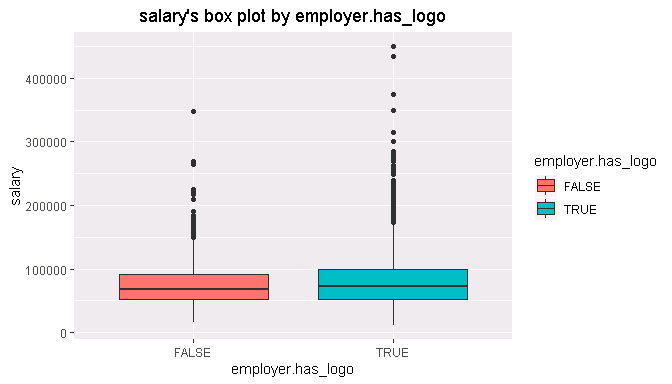

**[ address.metro.station ]**  
1. Analysis of Variance

Analysis of Variance Table : address.metro.station

|  | Df | Sum.Sq | Mean.Sq | F.value | Pr..F. |
| --- | --- | --- | --- | --- | --- |
| address.metro.station | 224 | 505623459382 | 2257247587 | 1.71 | 0 |
| Residuals | 3734 | 4940909712314 | 1323221669 | NA | NA |

2. Simple Linear Model Information

Coefficients:

Simple Linear Model coefficients : address.metro.station

|  | Estimate | Std. Error | t value | Pr(>\|t\|) |
| --- | --- | --- | --- | --- |
| (Intercept) | 67378.52 | 4511.90 | 14.93 | 0.00 |
| address.metro.stationАвтозаводская | 17992.70 | 6287.64 | 2.86 | 0.00 |
| address.metro.stationАкадемическая | 17253.73 | 9688.63 | 1.78 | 0.08 |
| address.metro.stationАлександровский сад | 40096.48 | 15520.77 | 2.58 | 0.01 |
| address.metro.stationАлексеевская | 10675.74 | 6484.55 | 1.65 | 0.10 |
| address.metro.stationАлма-Атинская | 17110.48 | 16881.99 | 1.01 | 0.31 |
| address.metro.stationАлтуфьево | 4545.45 | 7699.06 | 0.59 | 0.55 |
| address.metro.stationАндроновка | -700.40 | 13629.38 | -0.05 | 0.96 |
| address.metro.stationАннино | 6394.12 | 7626.51 | 0.84 | 0.40 |
| address.metro.stationАрбатская | 7213.14 | 15520.77 | 0.46 | 0.64 |
| address.metro.stationАэропорт | 1833.14 | 9130.60 | 0.20 | 0.84 |
| address.metro.stationБабушкинская | 9688.56 | 9688.63 | 1.00 | 0.32 |
| address.metro.stationБагратионовская | 24053.35 | 18739.33 | 1.28 | 0.20 |
| address.metro.stationБаррикадная | 58621.48 | 36654.86 | 1.60 | 0.11 |
| address.metro.stationБауманская | 26568.26 | 5818.89 | 4.57 | 0.00 |
| address.metro.stationБеговая | 14834.24 | 8123.15 | 1.83 | 0.07 |
| address.metro.stationБеломорская | -39878.52 | 36654.86 | -1.09 | 0.28 |
| address.metro.stationБелорусская | 3249.15 | 6356.58 | 0.51 | 0.61 |
| address.metro.stationБеляево | 696.12 | 14470.28 | 0.05 | 0.96 |
| address.metro.stationБибирево | 5872.85 | 8123.15 | 0.72 | 0.47 |
| address.metro.stationБиблиотека им.Ленина | -12368.52 | 16881.99 | -0.73 | 0.46 |
| address.metro.stationБоровское шоссе | 9546.48 | 26114.52 | 0.37 | 0.71 |
| address.metro.stationБотанический сад | 9712.59 | 7626.51 | 1.27 | 0.20 |
| address.metro.stationБратиславская | -4600.39 | 8972.39 | -0.51 | 0.61 |
| address.metro.stationБульвар Дмитрия Донского | -502.27 | 15520.77 | -0.03 | 0.97 |
| address.metro.stationБульвар Рокоссовского | -15677.93 | 9909.28 | -1.58 | 0.11 |
| address.metro.stationБутырская | -15785.67 | 14470.28 | -1.09 | 0.28 |
| address.metro.stationВаршавская | 8952.21 | 9909.28 | 0.90 | 0.37 |
| address.metro.stationВДНХ | 14921.15 | 8825.45 | 1.69 | 0.09 |
| address.metro.stationВерхние Котлы | -4870.34 | 11859.60 | -0.41 | 0.68 |

[output cut: 195 more lines]

3. Visualization:

[figure not shown]

**[ address.metro.line ]**  
1. Analysis of Variance

Analysis of Variance Table : address.metro.line

|  | Df | Sum.Sq | Mean.Sq | F.value | Pr..F. |
| --- | --- | --- | --- | --- | --- |
| address.metro.line | 17 | 109193858431 | 6423168143 | 4.74 | 0 |
| Residuals | 3941 | 5337339313265 | 1354310914 | NA | NA |

2. Simple Linear Model Information

Coefficients:

Simple Linear Model coefficients : address.metro.line

|  | Estimate | Std. Error | t value | Pr(>\|t\|) |
| --- | --- | --- | --- | --- |
| (Intercept) | 83053.32 | 1671.05 | 49.70 | 0.00 |
| address.metro.lineБольшая кольцевая линия | 372.87 | 7547.50 | 0.05 | 0.96 |
| address.metro.lineБутовская | -6058.32 | 16542.51 | -0.37 | 0.71 |
| address.metro.lineЗамоскворецкая | -5632.43 | 2276.17 | -2.47 | 0.01 |
| address.metro.lineКалининская | -4777.31 | 2722.98 | -1.75 | 0.08 |
| address.metro.lineКалужско-Рижская | -3982.85 | 2464.06 | -1.62 | 0.11 |
| address.metro.lineКаховская | 2372.61 | 7695.58 | 0.31 | 0.76 |
| address.metro.lineКольцевая | 1678.38 | 3114.83 | 0.54 | 0.59 |
| address.metro.lineЛюблинско-Дмитровская | -14784.78 | 2869.04 | -5.15 | 0.00 |
| address.metro.lineМонорельс | -28010.28 | 8833.57 | -3.17 | 0.00 |
| address.metro.lineМосковско-Петроградская | -30553.32 | 36838.88 | -0.83 | 0.41 |
| address.metro.lineМЦД - 1 | -16583.07 | 16542.51 | -1.00 | 0.32 |
| address.metro.lineМЦК | -12554.90 | 3347.28 | -3.75 | 0.00 |
| address.metro.lineНекрасовская | -19992.07 | 18476.20 | -1.08 | 0.28 |
| address.metro.lineСерпуховско-Тимирязевская | -7374.44 | 2264.38 | -3.26 | 0.00 |
| address.metro.lineСокольническая | -8021.04 | 2451.38 | -3.27 | 0.00 |
| address.metro.lineТаганско-Краснопресненская | -2440.72 | 2449.83 | -1.00 | 0.32 |
| address.metro.lineФилевская | 13549.83 | 4223.78 | 3.21 | 0.00 |

3. Visualization:

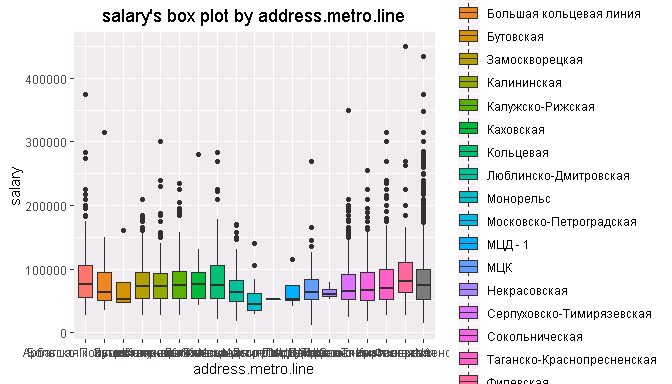

**[ experience ]**  
1. Analysis of Variance

Analysis of Variance Table : experience

|  | Df | Sum.Sq | Mean.Sq | F.value | Pr..F. |
| --- | --- | --- | --- | --- | --- |
| experience | 3 | 331424431316 | 110474810439 | 77.05 | 0 |
| Residuals | 7725 | 11076023887184 | 1433789500 | NA | NA |

2. Simple Linear Model Information

Coefficients:

Simple Linear Model coefficients : experience

|  | Estimate | Std. Error | t value | Pr(>\|t\|) |
| --- | --- | --- | --- | --- |
| (Intercept) | 73812.28 | 943.11 | 78.27 | 0 |
| experienceОт 1 года до 3 лет | 3261.70 | 1113.29 | 2.93 | 0 |
| experienceОт 3 до 6 лет | 13264.52 | 1301.38 | 10.19 | 0 |
| experienceБолее 6 лет | 31081.43 | 2634.23 | 11.80 | 0 |

3. Visualization:

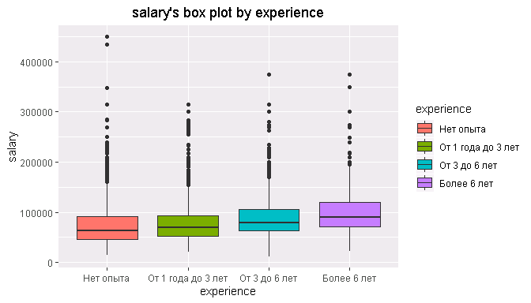

**[ accept_handicapped ]**  
1. Analysis of Variance

Analysis of Variance Table : accept\_handicapped

|  | Df | Sum.Sq | Mean.Sq | F.value | Pr..F. |
| --- | --- | --- | --- | --- | --- |
| accept_handicapped | 1 | 3169831266 | 3169831266 | 2.15 | 0.14 |
| Residuals | 7727 | 11404278487234 | 1475899895 | NA | NA |

2. Simple Linear Model Information

Residual standard error: 38417 on 7727 degrees of freedom Multiple R-squared: 0.00028, Adjusted R-squared: 0.00015 F-statistic: 2 on 1 and 7727 DF, p-value: 0.142821746062082

Coefficients:

Simple Linear Model coefficients : accept\_handicapped

|  | Estimate | Std. Error | t value | Pr(>\|t\|) |
| --- | --- | --- | --- | --- |
| (Intercept) | 79618.55 | 439.18 | 181.29 | 0.00 |
| accept_handicappedTRUE | -6448.32 | 4400.05 | -1.47 | 0.14 |

3. Visualization:

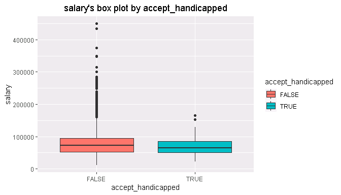

**[ accept_kids ]**  
1. Analysis of Variance

Analysis of Variance Table : accept\_kids

|  | Df | Sum.Sq | Mean.Sq | F.value | Pr..F. |
| --- | --- | --- | --- | --- | --- |
| accept_kids | 1 | 2339371712 | 2339371712 | 1.58 | 0.21 |
| Residuals | 7727 | 11405108946788 | 1476007370 | NA | NA |

2. Simple Linear Model Information

Residual standard error: 38419 on 7727 degrees of freedom Multiple R-squared: 0.00021, Adjusted R-squared: 0.00008 F-statistic: 2 on 1 and 7727 DF, p-value: 0.2080896994541

Coefficients:

Simple Linear Model coefficients : accept\_kids

|  | Estimate | Std. Error | t value | Pr(>\|t\|) |
| --- | --- | --- | --- | --- |
| (Intercept) | 79565.15 | 437.09 | 182.04 | 0.00 |
| accept_kidsTRUE | -27930.15 | 22185.43 | -1.26 | 0.21 |

3. Visualization:

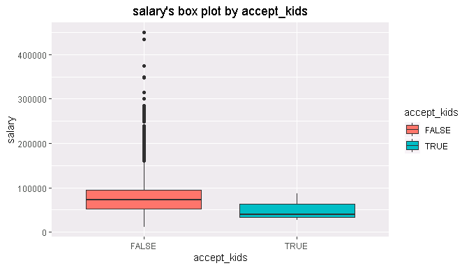

**[ has_test ]**  
1. Analysis of Variance

Analysis of Variance Table : has\_test

|  | Df | Sum.Sq | Mean.Sq | F.value | Pr..F. |
| --- | --- | --- | --- | --- | --- |
| has_test | 1 | 711638404 | 711638404 | 0.48 | 0.49 |
| Residuals | 7727 | 11406736680096 | 1476218025 | NA | NA |

2. Simple Linear Model Information

Residual standard error: 38422 on 7727 degrees of freedom Multiple R-squared: 0.00006, Adjusted R-squared: -0.00007 F-statistic: 0 on 1 and 7727 DF, p-value: 0.487507676139637

Coefficients:

Simple Linear Model coefficients : has\_test

|  | Estimate | Std. Error | t value | Pr(>\|t\|) |
| --- | --- | --- | --- | --- |
| (Intercept) | 79512.65 | 441.13 | 180.25 | 0.00 |
| has_testTRUE | 2251.73 | 3243.12 | 0.69 | 0.49 |

3. Visualization:

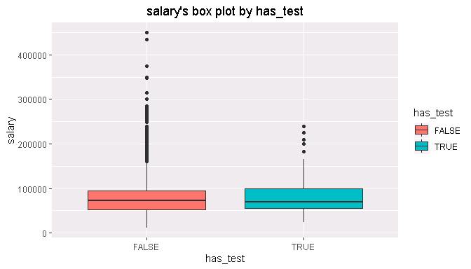

**[ employer.type ]**  
1. Analysis of Variance

Analysis of Variance Table : employer.type

|  | Df | Sum.Sq | Mean.Sq | F.value | Pr..F. |
| --- | --- | --- | --- | --- | --- |
| employer.type | 3 | 46064960240 | 15354986747 | 10.42 | 0 |
| Residuals | 7699 | 11341327215186 | 1473090949 | NA | NA |

2. Simple Linear Model Information

Residual standard error: 38381 on 7699 degrees of freedom Multiple R-squared: 0.00405, Adjusted R-squared: 0.00366 F-statistic: 10 on 3 and 7699 DF, p-value: 0.000000109300275553926

Coefficients:

Simple Linear Model coefficients : employer.type

|  | Estimate | Std. Error | t value | Pr(>\|t\|) |
| --- | --- | --- | --- | --- |
| (Intercept) | 86867.79 | 1456.92 | 59.62 | 0.00 |
| employer.typecompany | -8123.80 | 1528.30 | -5.32 | 0.00 |
| employer.typeprivate_recruiter | -11031.70 | 8134.50 | -1.36 | 0.18 |
| employer.typeproject_director | 170.17 | 4722.49 | 0.04 | 0.97 |

3. Visualization:

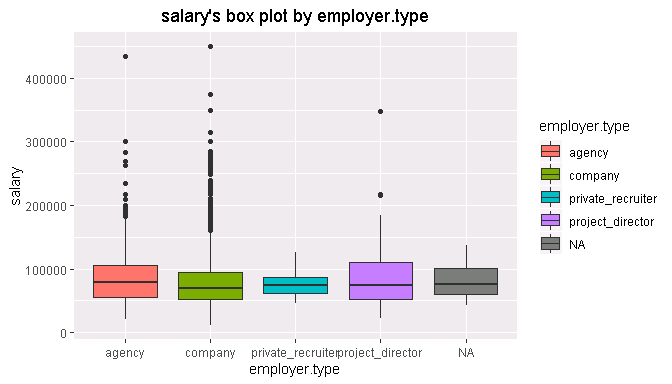

**[ employer.area ]**  
1. Analysis of Variance

Analysis of Variance Table : employer.area

|  | Df | Sum.Sq | Mean.Sq | F.value | Pr..F. |
| --- | --- | --- | --- | --- | --- |
| employer.area | 144 | 372363475113 | 2585857466 | 1.77 | 0 |
| Residuals | 7558 | 11015028700313 | 1457399934 | NA | NA |

2. Simple Linear Model Information

Coefficients:

Simple Linear Model coefficients : employer.area

|  | Estimate | Std. Error | t value | Pr(>\|t\|) |
| --- | --- | --- | --- | --- |
| (Intercept) | 68512.50 | 38175.91 | 1.79 | 0.07 |
| employer.areaАксай (Ростовская область) | 7637.50 | 41819.61 | 0.18 | 0.86 |
| employer.areaАлматы | 159530.42 | 53988.89 | 2.95 | 0.00 |
| employer.areaАлушта | -27405.00 | 53988.89 | -0.51 | 0.61 |
| employer.areaАрциз | 31487.50 | 53988.89 | 0.58 | 0.56 |
| employer.areaАстрахань | -14512.50 | 53988.89 | -0.27 | 0.79 |
| employer.areaБалашиха | -13175.00 | 46755.75 | -0.28 | 0.78 |
| employer.areaБарановичи | 16487.50 | 53988.89 | 0.31 | 0.76 |
| employer.areaБарнаул | -12679.17 | 44081.74 | -0.29 | 0.77 |
| employer.areaБатайск | 66487.50 | 53988.89 | 1.23 | 0.22 |
| employer.areaБелгород | 12276.67 | 41234.69 | 0.30 | 0.77 |
| employer.areaБеслан | -3262.50 | 53988.89 | -0.06 | 0.95 |
| employer.areaБрянск | 50975.00 | 46755.75 | 1.09 | 0.28 |
| employer.areaБузулук | 6487.50 | 53988.89 | 0.12 | 0.90 |
| employer.areaВеликобритания | -33712.50 | 53988.89 | -0.62 | 0.53 |
| employer.areaВидное | 4987.50 | 53988.89 | 0.09 | 0.93 |
| employer.areaВладивосток | 22101.25 | 39118.66 | 0.56 | 0.57 |
| employer.areaВладимир | 28537.50 | 40811.76 | 0.70 | 0.48 |
| employer.areaВолгоград | 36725.83 | 41234.69 | 0.89 | 0.37 |
| employer.areaВологда | -9001.50 | 41819.61 | -0.22 | 0.83 |
| employer.areaВолоколамск | -18512.50 | 53988.89 | -0.34 | 0.73 |
| employer.areaВоронеж | 27713.64 | 39033.90 | 0.71 | 0.48 |
| employer.areaВосточно-Центральный округ | 6487.50 | 53988.89 | 0.12 | 0.90 |
| employer.areaГолицыно | 52987.50 | 46755.75 | 1.13 | 0.26 |
| employer.areaДзержинск (Нижегородская область) | -31972.50 | 53988.89 | -0.59 | 0.55 |
| employer.areaДзержинский | -14137.50 | 53988.89 | -0.26 | 0.79 |
| employer.areaДнепр (Днепропетровск) | 18987.50 | 53988.89 | 0.35 | 0.73 |
| employer.areaДомодедово | 18987.50 | 44081.74 | 0.43 | 0.67 |
| employer.areaЕкатеринбург | 18645.25 | 38366.31 | 0.49 | 0.63 |
| employer.areaЖелезнодорожный | 16237.50 | 46755.75 | 0.35 | 0.73 |

[output cut: 115 more lines]

3. Visualization:

[figure not shown]

**[ employer.industries ]**  
1. Analysis of Variance

Analysis of Variance Table : employer.industries

|  | Df | Sum.Sq | Mean.Sq | F.value | Pr..F. |
| --- | --- | --- | --- | --- | --- |
| employer.industries | 1347 | 2936659471003 | 2180148085 | 1.64 | 0 |
| Residuals | 6355 | 8450732704423 | 1329776979 | NA | NA |

2. Simple Linear Model Information

Coefficients:

Simple Linear Model coefficients : employer.industries

|  | Estimate | Std. Error | t value | Pr(>\|t\|) |
| --- | --- | --- | --- | --- |
| (Intercept) | 80274.68 | 775.70 | 103.49 | 0.00 |
| employer.industriesАвиаперевозки | -22965.48 | 11557.66 | -1.99 | 0.05 |
| employer.industriesАвиаперевозки::Железнодорожные перевозки | -29004.68 | 21068.00 | -1.38 | 0.17 |
| employer.industriesАвиационная, вертолетная, аэрокосмическая промышленность | -25674.68 | 36474.36 | -0.70 | 0.48 |
| employer.industriesАвиационная, вертолетная, аэрокосмическая промышленность::Двигатели (монтаж, сервис, ремонт) | -7774.68 | 36474.36 | -0.21 | 0.83 |
| employer.industriesАвтозапчасти, шины (розничная торговля) | 19225.32 | 25797.10 | 0.75 | 0.46 |
| employer.industriesАвтозапчасти, шины (розничная торговля)::Автокомпоненты, запчасти, шины (продвижение, оптовая торговля) | -24617.54 | 13804.70 | -1.78 | 0.07 |
| employer.industriesАвтозапчасти, шины (розничная торговля)::Автокомпоненты, запчасти, шины (продвижение, оптовая торговля)::Автокомпоненты, запчасти (производство) | -7936.59 | 5966.22 | -1.33 | 0.18 |
| employer.industriesАвтозапчасти, шины (розничная торговля)::Автокомпоненты, запчасти, шины (продвижение, оптовая торговля)::Автокомпоненты, запчасти (производство)::ГСМ, топливо (розничная торговля)::… | -17274.68 | 36474.36 | -0.47 | 0.64 |
| employer.industriesАвтозапчасти, шины (розничная торговля)::Автокомпоненты, запчасти, шины (продвижение, оптовая торговля)::Автокомпоненты, запчасти (производство)::Металлические изделия, металлоконст… | 26825.32 | 16326.58 | 1.64 | 0.10 |
| employer.industriesАвтозапчасти, шины (розничная торговля)::Автокомпоненты, запчасти, шины (продвижение, оптовая торговля)::Автокомпоненты, запчасти (производство)::Разработка программного обеспечения | -22524.68 | 25797.10 | -0.87 | 0.38 |
| employer.industriesАвтозапчасти, шины (розничная торговля)::Автокомпоненты, запчасти, шины (продвижение, оптовая торговля)::Интернет-магазин | -17274.68 | 36474.36 | -0.47 | 0.64 |
| employer.industriesАвтозапчасти, шины (розничная торговля)::Интернет-магазин | 9725.32 | 36474.36 | 0.27 | 0.79 |
| employer.industriesАвтокомпоненты, запчасти (производство) | -462.81 | 12916.03 | -0.04 | 0.97 |
| employer.industriesАвтокомпоненты, запчасти (производство)::Розничная торговля автомобилями (дилерский центр) | -3791.43 | 21068.00 | -0.18 | 0.86 |
| employer.industriesАвтокомпоненты, запчасти, шины (продвижение, оптовая торговля) | -28524.68 | 21068.00 | -1.35 | 0.18 |
| employer.industriesАвтокомпоненты, запчасти, шины (продвижение, оптовая торговля)::Автокомпоненты, запчасти (производство) | -23630.93 | 18249.55 | -1.29 | 0.20 |
| employer.industriesАвтокомпоненты, запчасти, шины (продвижение, оптовая торговля)::Автокомпоненты, запчасти (производство)::Легковые, грузовые автомобили, мототехника, автобусы, троллейбусы (продвижен… | 14725.32 | 36474.36 | 0.40 | 0.69 |
| employer.industriesАвтокомпоненты, запчасти, шины (продвижение, оптовая торговля)::Розничная торговля автомобилями (дилерский центр) | -6459.68 | 21068.00 | -0.31 | 0.76 |
| employer.industriesАвтомобильные перевозки | -13585.75 | 7193.54 | -1.89 | 0.06 |
| employer.industriesАвтомобильные перевозки::Авиаперевозки::Морские, речные перевозки::Железнодорожные перевозки | -43524.68 | 36474.36 | -1.19 | 0.23 |
| employer.industriesАвтомобильные перевозки::Авиаперевозки::Складские услуги::Железнодорожные перевозки | -30274.68 | 36474.36 | -0.83 | 0.41 |
| employer.industriesАвтомобильные перевозки::Авиаперевозки::Складские услуги::Морские, речные перевозки | -27774.68 | 36474.36 | -0.76 | 0.45 |
| employer.industriesАвтомобильные перевозки::Авиаперевозки::Складские услуги::Морские, речные перевозки::Железнодорожные перевозки | -7194.68 | 36474.36 | -0.20 | 0.84 |
| employer.industriesАвтомобильные перевозки::Авиаперевозки::Складские услуги::Транспортно-логистические комплексы, порты (воздушный, водный, железнодорожный)::Фармацевтическая продукция (продвижение, о… | 3725.32 | 36474.36 | 0.10 | 0.92 |
| employer.industriesАвтомобильные перевозки::Авиаперевозки::Транспортно-логистические комплексы, порты (воздушный, водный, железнодорожный)::Морские, речные перевозки::Железнодорожные перевозки | 49725.32 | 36474.36 | 1.36 | 0.17 |
| employer.industriesАвтомобильные перевозки::Дорожно-строительная техника, сельскохозяйственная и другая спец.техника, оборудование, лифты, погрузочно-разгрузочное, складское оборудование (продвижение,… | 19725.32 | 36474.36 | 0.54 | 0.59 |
| employer.industriesАвтомобильные перевозки::Складские услуги::Железнодорожные перевозки | -27774.68 | 36474.36 | -0.76 | 0.45 |
| employer.industriesАвтомобильные перевозки::Складские услуги::Транспортно-логистические комплексы, порты (воздушный, водный, железнодорожный) | -12024.68 | 25797.10 | -0.47 | 0.64 |
| employer.industriesАвтомобильные перевозки::Складские услуги::Транспортно-логистические комплексы, порты (воздушный, водный, железнодорожный)::Железнодорожные перевозки | -35274.68 | 36474.36 | -0.97 | 0.33 |

[output cut: 1318 more lines]

3. Visualization:

[figure not shown]

**[ employer.has_wiki ]**  
1. Analysis of Variance

Analysis of Variance Table : employer.has\_wiki

|  | Df | Sum.Sq | Mean.Sq | F.value | Pr..F. |
| --- | --- | --- | --- | --- | --- |
| employer.has_wiki | 1 | 6099645 | 6099645 | 0 | 0.95 |
| Residuals | 7701 | 11387386075781 | 1478689271 | NA | NA |

2. Simple Linear Model Information

Residual standard error: 38454 on 7701 degrees of freedom Multiple R-squared: 0, Adjusted R-squared: -0.00013 F-statistic: 0 on 1 and 7701 DF, p-value: 0.948791594357913

Coefficients:

Simple Linear Model coefficients : employer.has\_wiki

|  | Estimate | Std. Error | t value | Pr(>\|t\|) |
| --- | --- | --- | --- | --- |
| (Intercept) | 79552.69 | 450.99 | 176.39 | 0.00 |
| employer.has_wikiTRUE | -122.17 | 1902.20 | -0.06 | 0.95 |

3. Visualization:

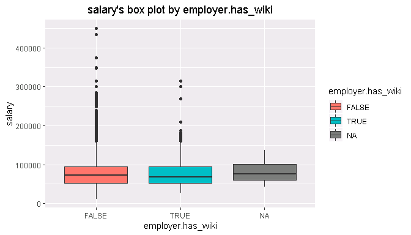

**[ employer.legal_form ]**  
1. Analysis of Variance

Analysis of Variance Table : employer.legal\_form

|  | Df | Sum.Sq | Mean.Sq | F.value | Pr..F. |
| --- | --- | --- | --- | --- | --- |
| employer.legal_form | 19 | 77921949169 | 4101155219 | 4.03 | 0 |
| Residuals | 130 | 132425750574 | 1018659620 | NA | NA |

2. Simple Linear Model Information

Coefficients:

Simple Linear Model coefficients : employer.legal\_form

|  | Estimate | Std. Error | t value | Pr(>\|t\|) |
| --- | --- | --- | --- | --- |
| (Intercept) | 68512.50 | 31916.45 | 2.15 | 0.03 |
| employer.legal_formakciova spolecnost | 25447.50 | 45136.67 | 0.56 | 0.57 |
| employer.legal_formAktiengesellschaft | 496.50 | 34962.72 | 0.01 | 0.99 |
| employer.legal_formGmbH & Co. KG | 34627.50 | 36853.94 | 0.94 | 0.35 |
| employer.legal_formOy | -10788.67 | 36853.94 | -0.29 | 0.77 |
| employer.legal_formpublic limited company | -12775.50 | 34962.72 | -0.37 | 0.72 |
| employer.legal_formакционерное общество | 3615.15 | 32369.19 | 0.11 | 0.91 |
| employer.legal_formдочернее общество | 246487.50 | 45136.67 | 5.46 | 0.00 |
| employer.legal_formзарегистрированное общество в Германии | -34686.90 | 45136.67 | -0.77 | 0.44 |
| employer.legal_formкоммандитное товарищество | -4567.50 | 45136.67 | -0.10 | 0.92 |
| employer.legal_formконсорциум | 17048.93 | 34120.12 | 0.50 | 0.62 |
| employer.legal_formкорпорация | 26487.50 | 45136.67 | 0.59 | 0.56 |
| employer.legal_formНезависимые агентства и корпорации Федерального правительства США | 41487.50 | 45136.67 | 0.92 | 0.36 |
| employer.legal_formнепубличное акционерное общество | 4920.00 | 34473.70 | 0.14 | 0.89 |
| employer.legal_formобщество с ограниченной ответственностью | 20758.45 | 32667.53 | 0.64 | 0.53 |
| employer.legal_formпубличная компания | -2033.13 | 33219.69 | -0.06 | 0.95 |
| employer.legal_formпубличное акционерное общество | 20329.07 | 32502.12 | 0.63 | 0.53 |
| employer.legal_formунитарное предприятие | -8221.50 | 45136.67 | -0.18 | 0.86 |
| employer.legal_formфонд | 41487.50 | 45136.67 | 0.92 | 0.36 |
| employer.legal_formчастная компания | -177.55 | 32841.75 | -0.01 | 1.00 |

3. Visualization:

[figure not shown]

**[ employer.wiki_industry ]**  
1. Analysis of Variance

Analysis of Variance Table : employer.wiki\_industry

|  | Df | Sum.Sq | Mean.Sq | F.value | Pr..F. |
| --- | --- | --- | --- | --- | --- |
| employer.wiki_industry | 41 | 111091183085 | 2709541051 | 1.64 | 0.03 |
| Residuals | 86 | 142486787864 | 1656823115 | NA | NA |

2. Simple Linear Model Information

Coefficients:

Simple Linear Model coefficients : employer.wiki\_industry

|  | Estimate | Std. Error | t value | Pr(>\|t\|) |
| --- | --- | --- | --- | --- |
| (Intercept) | 73307.83 | 14391.07 | 5.09 | 0.00 |
| employer.wiki_industryавиационная промышленность | -27632.83 | 43173.21 | -0.64 | 0.52 |
| employer.wiki_industryавтомобильная промышленность | 2082.17 | 23204.90 | 0.09 | 0.93 |
| employer.wiki_industryАвтомобильный дилер | 57994.67 | 17027.74 | 3.41 | 0.00 |
| employer.wiki_industryАСУ ТП | -9362.83 | 43173.21 | -0.22 | 0.83 |
| employer.wiki_industryаудит | -40682.83 | 43173.21 | -0.94 | 0.35 |
| employer.wiki_industryбытовая электроника | 16692.17 | 43173.21 | 0.39 | 0.70 |
| employer.wiki_industryводный транспорт | -26327.83 | 43173.21 | -0.61 | 0.54 |
| employer.wiki_industryгазовая промышленность | 18042.17 | 43173.21 | 0.42 | 0.68 |
| employer.wiki_industryгостиничное дело | -19182.96 | 32179.41 | -0.60 | 0.55 |
| employer.wiki_industryдевелопмент | -10655.92 | 19307.65 | -0.55 | 0.58 |
| employer.wiki_industryинвестиции | 91992.17 | 43173.21 | 2.13 | 0.04 |
| employer.wiki_industryиндустрия компьютерных игр | -1185.96 | 24926.06 | -0.05 | 0.96 |
| employer.wiki_industryкиноиндустрия | 7692.17 | 32179.41 | 0.24 | 0.81 |
| employer.wiki_industryлёгкая промышленность | -21107.83 | 43173.21 | -0.49 | 0.63 |
| employer.wiki_industryЛизинг автомобилей | 64574.67 | 21982.72 | 2.94 | 0.00 |
| employer.wiki_industryмаркетинг | 8254.67 | 32179.41 | 0.26 | 0.80 |
| employer.wiki_industryмашиностроение | -4900.33 | 32179.41 | -0.15 | 0.88 |
| employer.wiki_industryОнлайн-рекрутмент | 77419.67 | 43173.21 | 1.79 | 0.08 |
| employer.wiki_industryоптовая торговля | 12822.17 | 43173.21 | 0.30 | 0.77 |
| employer.wiki_industryпароходство | -31025.83 | 43173.21 | -0.72 | 0.47 |
| employer.wiki_industryпищевая промышленность | 17704.67 | 32179.41 | 0.55 | 0.58 |
| employer.wiki_industryПолупроводниковая промышленность | 36312.17 | 43173.21 | 0.84 | 0.40 |
| employer.wiki_industryрозничная торговля | -3809.00 | 17295.91 | -0.22 | 0.83 |
| employer.wiki_industryсамолётостроительное предприятие | 26742.17 | 43173.21 | 0.62 | 0.54 |
| employer.wiki_industryсвидание | -3807.83 | 32179.41 | -0.12 | 0.91 |
| employer.wiki_industryстанкостроение | -227.83 | 43173.21 | -0.01 | 1.00 |
| employer.wiki_industryтелекоммуникационная индустрия | 34425.42 | 21982.72 | 1.57 | 0.12 |
| employer.wiki_industryторговля | -9192.83 | 21982.72 | -0.42 | 0.68 |
| employer.wiki_industryтуризм | -5057.83 | 43173.21 | -0.12 | 0.91 |
| employer.wiki_industryуправление персоналом | 10864.67 | 32179.41 | 0.34 | 0.74 |
| employer.wiki_industryфармацевтическая промышленность | 13474.67 | 43173.21 | 0.31 | 0.76 |
| employer.wiki_industryФарфоро-фаянсовая промышленность | -3707.83 | 43173.21 | -0.09 | 0.93 |
| employer.wiki_industryФинансовые технологии | -412.83 | 27556.80 | -0.01 | 0.99 |
| employer.wiki_industryфинансовые услуги | -27632.83 | 32179.41 | -0.86 | 0.39 |
| employer.wiki_industryхимическая промышленность | 46692.17 | 43173.21 | 1.08 | 0.28 |
| employer.wiki_industryХорология | 5226.92 | 32179.41 | 0.16 | 0.87 |
| employer.wiki_industryцеллюлозно-бумажная промышленность | -4795.33 | 43173.21 | -0.11 | 0.91 |
| employer.wiki_industryчёрная металлургия | -12407.83 | 43173.21 | -0.29 | 0.77 |
| employer.wiki_industryшвейная промышленность | 45492.17 | 32179.41 | 1.41 | 0.16 |
| employer.wiki_industryэлектронная коммерция | -18307.83 | 43173.21 | -0.42 | 0.67 |
| employer.wiki_industryэлектросвязь | -23307.83 | 43173.21 | -0.54 | 0.59 |

3. Visualization:

[figure not shown]

**[ employer.region ]**  
1. Analysis of Variance

Analysis of Variance Table : employer.region

|  | Df | Sum.Sq | Mean.Sq | F.value | Pr..F. |
| --- | --- | --- | --- | --- | --- |
| employer.region | 3 | 7857265142 | 2619088381 | 1.92 | 0.12 |
| Residuals | 4029 | 5499125207461 | 1364885879 | NA | NA |

2. Simple Linear Model Information

Coefficients:

Simple Linear Model coefficients : employer.region

|  | Estimate | Std. Error | t value | Pr(>\|t\|) |
| --- | --- | --- | --- | --- |
| (Intercept) | 60545.83 | 15082.47 | 4.01 | 0.00 |
| employer.regionДругой | 30704.17 | 23847.48 | 1.29 | 0.20 |
| employer.regionЗапад | 6433.01 | 16201.17 | 0.40 | 0.69 |
| employer.regionРоссия | 18112.64 | 15093.83 | 1.20 | 0.23 |

3. Visualization:

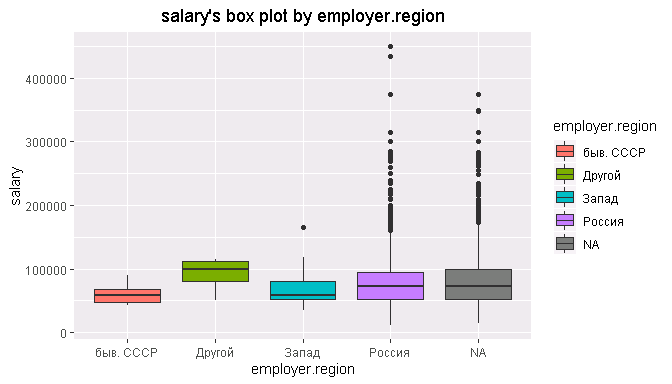

**[ employer.founded.cat ]**  
1. Analysis of Variance

Analysis of Variance Table : employer.founded.cat

|  | Df | Sum.Sq | Mean.Sq | F.value | Pr..F. |
| --- | --- | --- | --- | --- | --- |
| employer.founded.cat | 4 | 13775145358 | 3443786340 | 2.29 | 0.06 |
| Residuals | 381 | 572791465023 | 1503389672 | NA | NA |

2. Simple Linear Model Information

Coefficients:

Simple Linear Model coefficients : employer.founded.cat

|  | Estimate | Std. Error | t value | Pr(>\|t\|) |
| --- | --- | --- | --- | --- |
| (Intercept) | 67086.61 | 6553.93 | 10.24 | 0.00 |
| employer.founded.catOld | 7643.70 | 8107.57 | 0.94 | 0.35 |
| employer.founded.catX | 13480.78 | 8066.14 | 1.67 | 0.10 |
| employer.founded.catY | 17890.06 | 7115.08 | 2.51 | 0.01 |
| employer.founded.catZ | 5238.64 | 10702.52 | 0.49 | 0.62 |

3. Visualization:

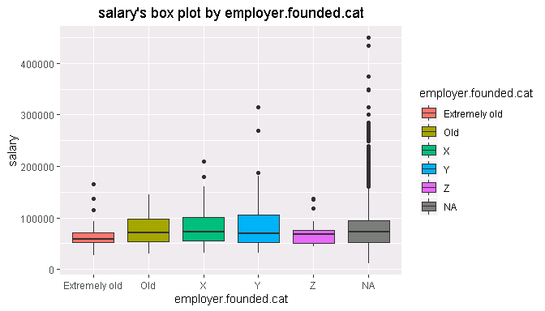

**[ employer.class ]**  
1. Analysis of Variance

Analysis of Variance Table : employer.class

|  | Df | Sum.Sq | Mean.Sq | F.value | Pr..F. |
| --- | --- | --- | --- | --- | --- |
| employer.class | 3 | 3110485544 | 1036828515 | 0.67 | 0.58 |
| Residuals | 68 | 105918286802 | 1557621865 | NA | NA |

2. Simple Linear Model Information

Coefficients:

Simple Linear Model coefficients : employer.class

|  | Estimate | Std. Error | t value | Pr(>\|t\|) |
| --- | --- | --- | --- | --- |
| (Intercept) | 55000.00 | 39466.72 | 1.39 | 0.17 |
| employer.classСреднее предприятие | 5685.00 | 42628.93 | 0.13 | 0.89 |
| employer.classКрупное предприятие | 26192.87 | 39884.37 | 0.66 | 0.51 |
| employer.classКорпорация | 28247.63 | 40548.20 | 0.70 | 0.49 |

3. Visualization:

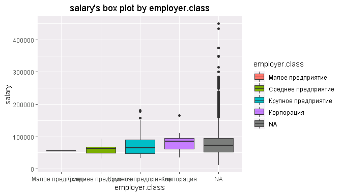

## 4.2 Grouped Relationship Between Variables

### 4.2.1 Grouped Correlation Coefficient

```
Numerical target variables are not supported.
```

### 4.2.2 Grouped Correlation Plot of Numerical Variables

```
Numerical target variables are not supported.
```